# Analyzing the Impact of Recession on Automobile Sales

## Data Description

The dataset includes the following variables:  
1. Date: The date of the observation.  
2. Recession: A binary variable indicating recession perion; 1 means it was recession, 0 means it was normal.  
3. Automobile_Sales: The number of vehicles sold during the period.  
4. GDP: The per capita GDP value in USD.  
5. Unemployment_Rate: The monthly unemployment rate.  
6. Consumer_Confidence: A synthetic index representing consumer confidence, which can impact consumer spending and automobile purchases.  
7. Seasonality_Weight: The weight representing the seasonality effect on automobile sales during the period.  
8. Price: The average vehicle price during the period.  
9. Advertising_Expenditure: The advertising expenditure of the company.  
10.Vehicle_Type: The type of vehicles sold; Supperminicar, Smallfamiliycar, Mediumfamilycar, Executivecar, Sports.  
11.Competition: The measure of competition in the market, such as the number of competitors or market share of major manufacturers.  
12.Month: Month of the observation extracted from Date..  
13.Year: Year of the observation extracted from Date.

## Recession Period

recession period 1 - year 1980  
recession period 2 - year 1981 to 1982  
recession period 3 - year 1991  
recession period 4 - year 2000 to 2001  
recession period 5 - year end 2007 to mid 2009  
recession period 6 - year 2020 -Feb to April (Covid-19 Impact)

#### Import required modules

```python
import numpy as np
import pandas as pd
import matplotlib
import matplotlib.pyplot as plt
import seaborn as sns
import folium
import json
%matplotlib inline
```

#### Read Automobile sales data from a csv file

```python
df = pd.read_csv('automobile_sales.csv', index_col=0)
```

### The data at a glance

```python
df
```

|  | Date | Year | Month | Recession | Consumer_Confidence | Seasonality_Weight | Price | Advertising_Expenditure | Competition | GDP | Growth_Rate | unemployment_rate | Automobile_Sales | Vehicle_Type | City |
| --- | --- | --- | --- | --- | --- | --- | --- | --- | --- | --- | --- | --- | --- | --- | --- |
| 0 | 1/31/1980 | 1980 | Jan | 1 | 108.24 | 0.50 | 27483.571 | 1558 | 7 | 60.223 | 0.010000 | 5.4 | 456.0 | Supperminicar | Georgia |
| 1 | 2/29/1980 | 1980 | Feb | 1 | 98.75 | 0.75 | 24308.678 | 3048 | 4 | 45.986 | -0.309594 | 4.8 | 555.9 | Supperminicar | New York |
| 2 | 3/31/1980 | 1980 | Mar | 1 | 107.48 | 0.20 | 28238.443 | 3137 | 3 | 35.141 | -0.308614 | 3.4 | 620.0 | Mediumfamilycar | New York |
| 3 | 4/30/1980 | 1980 | Apr | 1 | 115.01 | 1.00 | 32615.149 | 1653 | 7 | 45.673 | 0.230596 | 4.2 | 702.8 | Supperminicar | Illinois |
| 4 | 5/31/1980 | 1980 | May | 1 | 98.72 | 0.20 | 23829.233 | 1319 | 4 | 52.997 | 0.138197 | 5.3 | 770.4 | Smallfamiliycar | California |
| ... | ... | ... | ... | ... | ... | ... | ... | ... | ... | ... | ... | ... | ... | ... | ... |
| 523 | 8/31/2023 | 2023 | Aug | 0 | 103.36 | 0.25 | 27852.993 | 1793 | 6 | 57.169 | 0.764155 | 2.6 | 1579.6 | Executivecar | New York |
| 524 | 9/30/2023 | 2023 | Sep | 0 | 101.55 | 0.07 | 21183.704 | 1028 | 5 | 59.315 | 0.036180 | 2.5 | 1123.4 | Smallfamiliycar | California |
| 525 | 10/31/2023 | 2023 | Oct | 0 | 124.66 | 0.12 | 15975.589 | 1148 | 9 | 19.472 | -2.046169 | 2.5 | 1685.9 | Sports | California |
| 526 | 11/30/2023 | 2023 | Nov | 0 | 97.09 | 0.25 | 16862.288 | 4850 | 5 | 27.904 | 0.302179 | 2.9 | 2124.6 | Smallfamiliycar | Georgia |
| 527 | 12/31/2023 | 2023 | Dec | 0 | 95.92 | 0.34 | 25240.425 | 2319 | 3 | 13.518 | -1.064211 | 2.1 | 3538.5 | Smallfamiliycar | Georgia |

528 rows × 15 columns

#### Number of rows and columns

```python
df.shape
```

```
(528, 15)
```

##### 528 rows of data and 15 columns

#### Some information about data in columns

```python
df.info()
```

```
<class 'pandas.core.frame.DataFrame'>
Index: 528 entries, 0 to 527
Data columns (total 15 columns):
 #   Column                   Non-Null Count  Dtype
---  ------                   --------------  -----
 0   Date                     528 non-null    object
 1   Year                     528 non-null    int64
 2   Month                    528 non-null    object
 3   Recession                528 non-null    int64
 4   Consumer_Confidence      528 non-null    float64
 5   Seasonality_Weight       528 non-null    float64
 6   Price                    528 non-null    float64
 7   Advertising_Expenditure  528 non-null    int64
 8   Competition              528 non-null    int64
 9   GDP                      528 non-null    float64
 10  Growth_Rate              528 non-null    float64
 11  unemployment_rate        528 non-null    float64
 12  Automobile_Sales         528 non-null    float64
 13  Vehicle_Type             528 non-null    object
 14  City                     528 non-null    object
dtypes: float64(7), int64(4), object(4)
memory usage: 66.0+ KB
```

#### Missing values for each column

```python
df.isnull().sum()
```

```
Date                       0
Year                       0
Month                      0
Recession                  0
Consumer_Confidence        0
Seasonality_Weight         0
Price                      0
Advertising_Expenditure    0
Competition                0
GDP                        0
Growth_Rate                0
unemployment_rate          0
Automobile_Sales           0
Vehicle_Type               0
City                       0
dtype: int64
```

#### Descriptive Statistics of Numerical columns

```python
df.describe()
```

|  | Year | Recession | Consumer_Confidence | Seasonality_Weight | Price | Advertising_Expenditure | Competition | GDP | Growth_Rate | unemployment_rate | Automobile_Sales |
| --- | --- | --- | --- | --- | --- | --- | --- | --- | --- | --- | --- |
| count | 528.000000 | 528.000000 | 528.000000 | 528.000000 | 528.000000 | 528.000000 | 528.000000 | 528.000000 | 528.000000 | 528.000000 | 528.000000 |
| mean | 2001.500000 | 0.214015 | 101.140170 | 0.575795 | 24964.991956 | 3067.456439 | 6.064394 | 40.073903 | -0.242001 | 2.453977 | 2352.718068 |
| std | 12.710467 | 0.410526 | 10.601154 | 0.454477 | 4888.073433 | 1139.564637 | 1.968350 | 16.249714 | 0.861268 | 1.119019 | 1645.321284 |
| min | 1980.000000 | 0.000000 | 73.900000 | 0.000000 | 8793.663000 | 1009.000000 | 3.000000 | 12.508000 | -4.227601 | 1.000000 | 102.000000 |
| 25% | 1990.750000 | 0.000000 | 94.035000 | 0.250000 | 21453.300500 | 2083.500000 | 4.000000 | 27.237500 | -0.574049 | 1.600000 | 793.950000 |
| 50% | 2001.500000 | 0.000000 | 100.740000 | 0.500000 | 25038.691500 | 3072.000000 | 6.000000 | 39.214500 | -0.013162 | 2.300000 | 2182.600000 |
| 75% | 2012.250000 | 0.000000 | 108.240000 | 0.750000 | 28131.684750 | 4067.250000 | 8.000000 | 53.506500 | 0.388932 | 2.900000 | 3614.800000 |
| max | 2023.000000 | 1.000000 | 131.670000 | 1.500000 | 44263.657000 | 4983.000000 | 9.000000 | 70.374000 | 0.815074 | 6.000000 | 21147.000000 |

##### The ranges of values in numerical columns seem reasonable.

## Creating Visualizations for Data Analysis

#### Automobile sales fluctuation from year to year

```python
# Default style and font size of plots
sns.set_style('darkgrid')
matplotlib.rcParams['font.size'] = 14
matplotlib.rcParams['figure.figsize'] = (10, 6)
matplotlib.rcParams['figure.facecolor'] = '#00000000'
pd.set_option('display.max_columns', None)
```

```python
# Recession period data
df_rec = df[df['Recession'] == 1]

df_rec_sales = df_rec.groupby('Year')['Automobile_Sales'].sum().reset_index()
print("Total Sales during Recession period:")
df_rec_sales
```

```
Total Sales during Recession period:
```

|  | Year | Automobile_Sales |
| --- | --- | --- |
| 0 | 1980 | 8147.4 |
| 1 | 1981 | 7600.9 |
| 2 | 1982 | 7573.8 |
| 3 | 1983 | 589.0 |
| 4 | 1990 | 7138.8 |
| 5 | 1991 | 7870.7 |
| 6 | 1992 | 2026.2 |
| 7 | 2000 | 5467.5 |
| 8 | 2001 | 8305.6 |
| 9 | 2002 | 2704.6 |
| 10 | 2008 | 6103.3 |
| 11 | 2009 | 7580.3 |
| 12 | 2020 | 2174.3 |

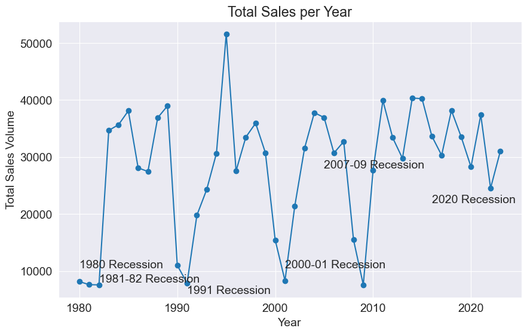

```python
df_year_t = df.groupby('Year')['Automobile_Sales'].sum()

# Create the line plot
df_year_t.plot(marker='o')
plt.title('Total Sales per Year')
plt.xlabel('Year')
plt.ylabel('Total Sales Volume')
# Annotate Recession years
plt.text(1980, 10500, '1980 Recession')
plt.text(1982, 8000, '1981-82 Recession')
plt.text(1991, 6000, '1991 Recession')
plt.text(2001, 10500, '2000-01 Recession')
plt.text(2005, 28000, '2007-09 Recession')
plt.text(2016, 22000, '2020 Recession')
plt.show()
```

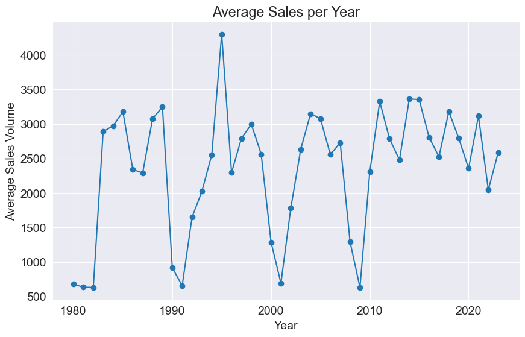

```python
df_year = df.groupby('Year')['Automobile_Sales'].mean()

# Create the line plot
df_year.plot(marker='o')
plt.title('Average Sales per Year')
plt.xlabel('Year')
plt.ylabel('Average Sales Volume')
plt.show()
```

#### Sales Trend by Vehicle Type

```python
vehicle_type = df['Vehicle_Type'].unique()
vehicle_type
```

```
array(['Supperminicar', 'Mediumfamilycar', 'Smallfamiliycar', 'Sports',
       'Executivecar'], dtype=object)
```

##### There are five types of vehicles: Suppermini car, Medium Family car, Small Family car, Sports car and Executive car.

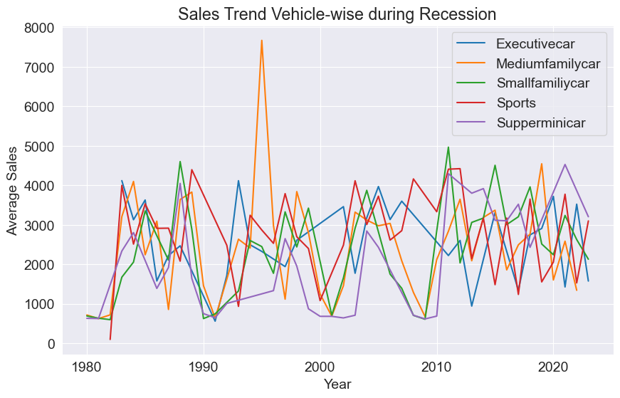

```python
df_veh = df.groupby(['Year','Vehicle_Type'], as_index=False)['Automobile_Sales'].mean()
df_veh.set_index('Year', inplace=True)
df_veh = df_veh.groupby(['Vehicle_Type'])['Automobile_Sales']

# Create the line plot
df_veh.plot(kind='line')
plt.xlabel('Year')
plt.ylabel('Average Sales')
plt.title('Sales Trend Vehicle-wise during Recession')
plt.legend()
plt.show()
```

#### Average sales during Recession

```python
df_rec_veh = df_rec.groupby(['Year', 'Vehicle_Type'], as_index=False)['Automobile_Sales'].mean()
df_rec_veh.sort_values(by=['Year', 'Automobile_Sales'], inplace=True)
df_rec_veh
```

|  | Year | Vehicle_Type | Automobile_Sales |
| --- | --- | --- | --- |
| 2 | 1980 | Supperminicar | 635.840000 |
| 1 | 1980 | Smallfamiliycar | 695.233333 |
| 0 | 1980 | Mediumfamilycar | 720.625000 |
| 3 | 1981 | Mediumfamilycar | 628.400000 |
| 5 | 1981 | Supperminicar | 630.900000 |
| 4 | 1981 | Smallfamiliycar | 638.420000 |
| 8 | 1982 | Sports | 102.000000 |
| 7 | 1982 | Smallfamiliycar | 602.225000 |
| 6 | 1982 | Mediumfamilycar | 723.271429 |
| 9 | 1983 | Smallfamiliycar | 589.000000 |
| 11 | 1990 | Smallfamiliycar | 629.257143 |
| 10 | 1990 | Mediumfamilycar | 659.733333 |
| 12 | 1990 | Supperminicar | 754.800000 |
| 13 | 1991 | Executivecar | 564.000000 |
| 14 | 1991 | Mediumfamilycar | 642.140000 |
| 16 | 1991 | Supperminicar | 650.050000 |
| 15 | 1991 | Smallfamiliycar | 747.900000 |
| 17 | 1992 | Mediumfamilycar | 670.050000 |
| 18 | 1992 | Supperminicar | 686.100000 |
| 21 | 2000 | Sports | 195.000000 |
| 20 | 2000 | Smallfamiliycar | 623.400000 |
| 19 | 2000 | Mediumfamilycar | 655.600000 |
| 22 | 2000 | Supperminicar | 686.300000 |
| 25 | 2001 | Supperminicar | 686.040000 |
| 23 | 2001 | Mediumfamilycar | 689.700000 |
| 24 | 2001 | Smallfamiliycar | 713.450000 |
| 28 | 2002 | Supperminicar | 646.250000 |
| 26 | 2002 | Mediumfamilycar | 697.600000 |
| 27 | 2002 | Smallfamiliycar | 714.500000 |
| 29 | 2008 | Mediumfamilycar | 636.200000 |
| 30 | 2008 | Smallfamiliycar | 710.566667 |
| 31 | 2008 | Supperminicar | 713.400000 |
| 33 | 2009 | Smallfamiliycar | 611.960000 |
| 34 | 2009 | Supperminicar | 621.275000 |
| 32 | 2009 | Mediumfamilycar | 678.466667 |
| 37 | 2020 | Sports | 214.000000 |
| 35 | 2020 | Mediumfamilycar | 644.950000 |
| 36 | 2020 | Smallfamiliycar | 670.400000 |

#### Sales during Recession and Non-Recession

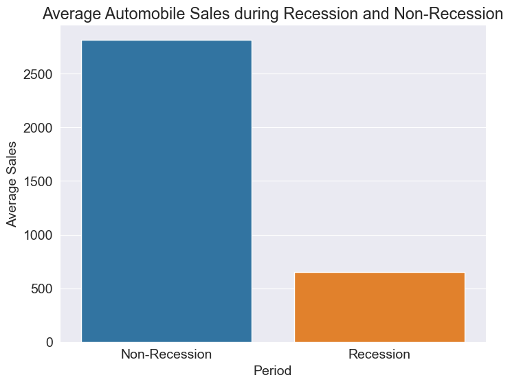

```python
new_df = df.groupby('Recession')['Automobile_Sales'].mean().reset_index()

# Create the bar chart using seaborn
plt.figure(figsize=(8, 6))
sns.barplot(x='Recession', y='Automobile_Sales', hue='Recession',  data=new_df, legend=False)
plt.xlabel('Period')
plt.ylabel('Average Sales')
plt.title('Average Automobile Sales during Recession and Non-Recession')
plt.xticks(ticks=[0, 1], labels=['Non-Recession', 'Recession'])
plt.show()
```

#### Sales of different vehicle types during a recession and a non-recession period.

```python
sales_rec_vehicle_type = df_rec.groupby('Vehicle_Type')['Automobile_Sales'].sum().reset_index()
print('Total sales during Recession period')
sales_rec_vehicle_type
```

```
Total sales during Recession period
```

|  | Vehicle_Type | Automobile_Sales |
| --- | --- | --- |
| 0 | Executivecar | 564.0 |
| 1 | Mediumfamilycar | 28343.6 |
| 2 | Smallfamiliycar | 23426.4 |
| 3 | Sports | 511.0 |
| 4 | Supperminicar | 20437.4 |

```python
# Non-Recession period data
df_non_rec = df[df['Recession']==0]

sales_non_rec_vehicle_type = df_non_rec.groupby('Vehicle_Type')['Automobile_Sales'].sum().reset_index()
print('Total sales during Non-Recession period')
sales_non_rec_vehicle_type
```

```
Total sales during Non-Recession period
```

|  | Vehicle_Type | Automobile_Sales |
| --- | --- | --- |
| 0 | Executivecar | 185364.10 |
| 1 | Mediumfamilycar | 369706.24 |
| 2 | Smallfamiliycar | 236728.60 |
| 3 | Sports | 264867.90 |
| 4 | Supperminicar | 112285.90 |

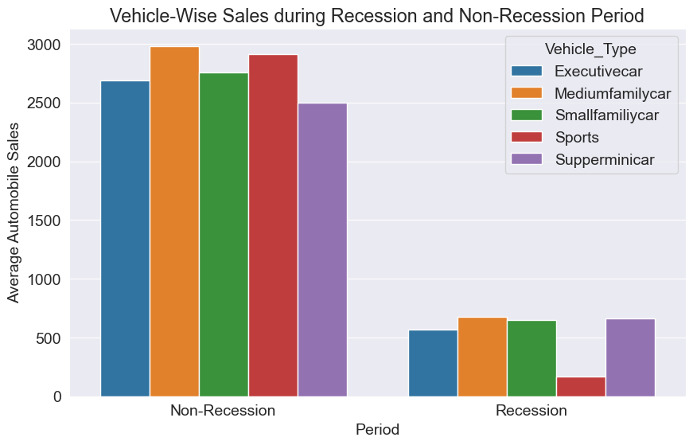

```python
df_bar=df.groupby(['Recession','Vehicle_Type'])['Automobile_Sales'].mean().reset_index()

# Create the grouped bar chart using seaborn
plt.figure(figsize=(10, 6))
sns.barplot(x='Recession', y='Automobile_Sales', hue='Vehicle_Type', data=df_bar)
plt.xticks(ticks=[0, 1], labels=['Non-Recession', 'Recession'])
plt.xlabel('Period')
plt.ylabel('Average Automobile Sales')
plt.title('Vehicle-Wise Sales during Recession and Non-Recession Period')
plt.show()
```

From this plot, we can understand that there is a drastic decline in the overall sales of the automobiles during recession.  
However, the most affected type of vehicle is executivecar and sports

#### GDP variation over time during recession and non-recession periods.

```python
df_gdp = df.groupby('Recession')['GDP'].mean()
print('Average GDP during Recession and Non-Recession period.')
df_gdp
```

```
Average GDP during Recession and Non-Recession period.
```

```
Recession
0    40.717111
1    37.711681
Name: GDP, dtype: float64
```

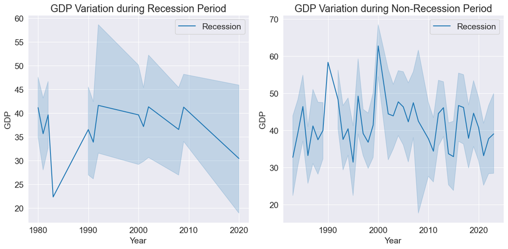

```python
# Recession period data
df_rec
# Non-Recession period data
df_non_rec

#Figure
fig=plt.figure(figsize=(12, 6))

#Create different axes for subploting
ax0 = fig.add_subplot(1, 2, 1)
ax1 = fig.add_subplot(1 , 2, 2 )

#Create Line plot for Recession period
sns.lineplot(x='Year', y='GDP', data=df_rec, label='Recession', ax=ax0)
ax0.set_xlabel('Year')
ax0.set_ylabel('GDP')
ax0.set_title('GDP Variation during Recession Period')

#Create Line plot for Non-Recession period
sns.lineplot(x='Year', y='GDP', data=df_non_rec, label='Recession', ax=ax1)
ax1.set_xlabel('Year')
ax1.set_ylabel('GDP')
ax1.set_title('GDP Variation during Non-Recession Period')

plt.tight_layout()
plt.show()
```

This plot shows that during the recession, the country's GDP was in a low range, which might have affected the company's overall sales.

#### Impact of Seasonality on Automobile Sales

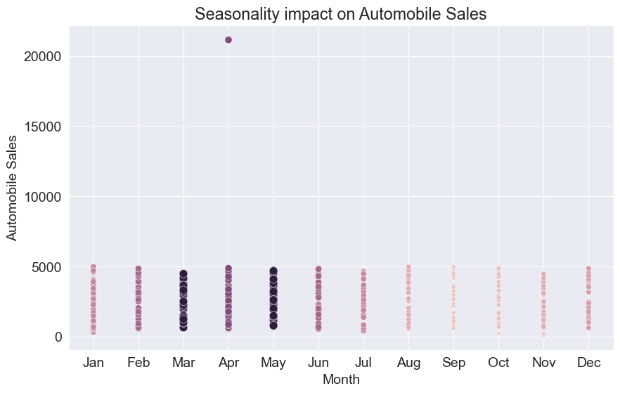

```python
# Size of bubble
size = df['Seasonality_Weight']

# Create the Bubble plot using seaborn
sns.scatterplot(data=df, x='Month', y='Automobile_Sales', size=size, hue='Seasonality_Weight', legend=False)
plt.xlabel('Month')
plt.ylabel('Automobile Sales')
plt.title('Seasonality impact on Automobile Sales')
plt.show()
```

From this plot, it is evident that seasonality has not affected the overall sales. However, there is a drastic rise in sales in April.

#### Relation between Consumer confidence and Sales volume

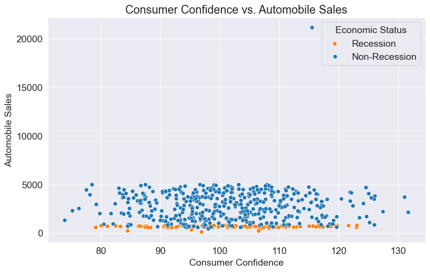

```python
legend_labels = ['Recession', 'Non-Recession']

# Create the Scatter plot
sns.scatterplot(data=df, x='Consumer_Confidence', y='Automobile_Sales', hue='Recession')
plt.xlabel('Consumer Confidence')
plt.ylabel('Automobile Sales')
plt.title('Consumer Confidence vs. Automobile Sales')
plt.legend(title='Economic Status', labels=legend_labels)
plt.show()
```

There is not much relation

#### Relation between Price and Sales volume

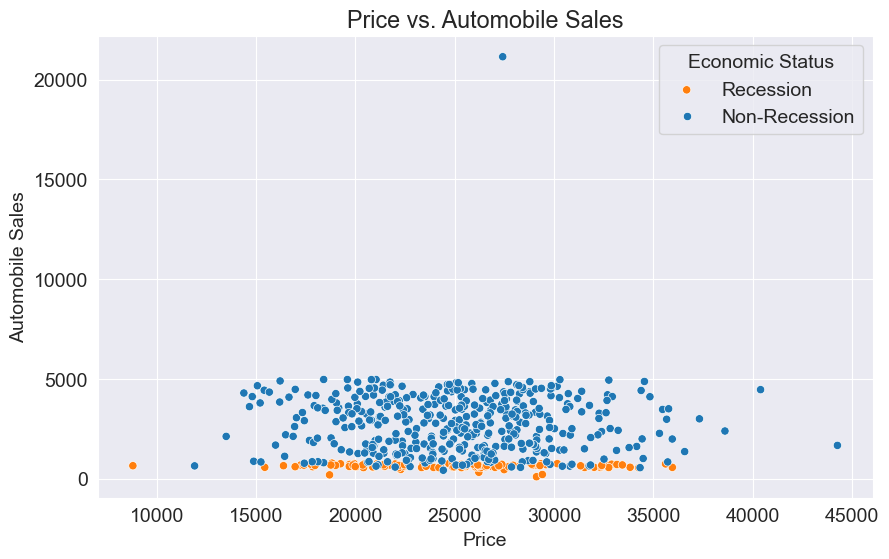

```python
legend_labels = ['Recession', 'Non-Recession']
# Create the Scatter plot
sns.scatterplot(data=df, x='Price', y='Automobile_Sales', hue='Recession')
plt.xlabel('Price')
plt.ylabel('Automobile Sales')
plt.title('Price vs. Automobile Sales')
plt.legend(title='Economic Status', labels=legend_labels)
plt.show()
```

There is not much relation

#### Advertising Expenditure

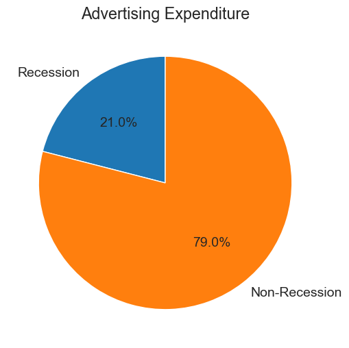

```python
# Calculate the total advertising expenditure for both periods
RAtotal = df_rec['Advertising_Expenditure'].sum()
NRAtotal = df_non_rec['Advertising_Expenditure'].sum()

# Create a pie chart for the advertising expenditure
plt.figure(figsize=(8, 6))
labels = ['Recession', 'Non-Recession']
sizes = [RAtotal, NRAtotal]
plt.pie(sizes, labels=labels, autopct='%1.1f%%', startangle=90)
plt.title('Advertising Expenditure')
plt.show()
```

There has been much more spending on advertisements during non-recession periods than during recession times.

#### Advertisement expenditure for each vehicle type during recession period.

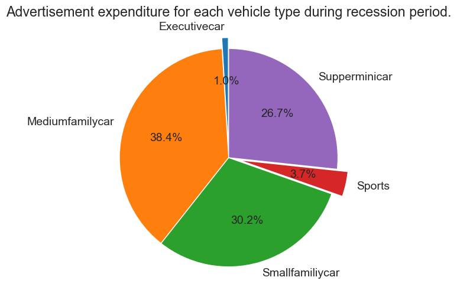

```python
# Calculate the sales volume by vehicle type during recessions
VTexpenditure = df_rec.groupby('Vehicle_Type')['Advertising_Expenditure'].sum()

# Create a pie chart for the share of each vehicle type in total expenditure during recessions
plt.figure(figsize=(6, 6))

labels = VTexpenditure.index
sizes = VTexpenditure.values
plt.pie(sizes, labels=labels, autopct='%1.1f%%', startangle=90, explode=[0.1,0,0,0.1,0])
plt.title('Advertisement expenditure for each vehicle type during recession period.')
plt.show()
```

During recession the advertisements were mostly focued on low price range vehicle.

#### Effect of Unemployment Rate on Vehicle Type and Sales.

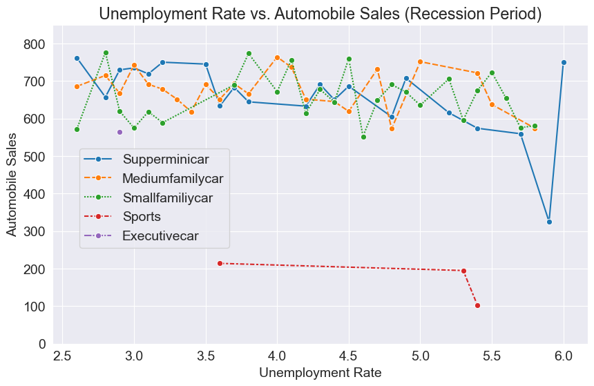

```python
# Create the Line plot
sns.lineplot(data=df_rec, x='unemployment_rate', y='Automobile_Sales',
             hue='Vehicle_Type', style='Vehicle_Type', markers='o', err_style=None)
plt.ylim(0,850)
plt.legend(loc=(0.05,.3))
plt.ylabel('Automobile Sales')
plt.xlabel('Unemployment Rate')
plt.title('Unemployment Rate vs. Automobile Sales (Recession Period)')
plt.show()
```

#### Impact of Recession on various offices/city sales.

```python
# Load json file for choropleth map
with open('us-states.json', 'r') as file:
    us_state = json.load(file)
```

```python
# Sales by city during Recession
sales_by_city = df_rec.groupby('City')['Automobile_Sales'].sum().reset_index()

# US map
us_map = folium.Map(location=[37.0902, -95.7129], zoom_start=4)

# Choropleth layer
choropleth = folium.Choropleth(
    geo_data=us_state,
    data=sales_by_city,
    columns=['City', 'Automobile_Sales'],
    key_on='feature.properties.name',
    fill_color='YlOrRd',
    fill_opacity=0.7,
    line_opacity=0.2,
    legend_name='Effect of Recession on Automobile Sales',
    reset=True
).add_to(us_map)

# Add tooltips to the choropleth layer
folium.features.GeoJsonTooltip(['name'], labels=True).add_to(choropleth.geojson)
us_map
```

Make this Notebook Trusted to load map: File -> Trust Notebook

[interactive chart not shown]